# Malathion - Quality Control and GWAS

Luciano V Cosme

2023-12-18

# Analysis code

## 1. Getting started: R libraries and software for QC

### 1.1 R libraries and software

```r
library(tidyverse)
library(here)
library(dplyr)
library(ggplot2)
library(colorout)
library(extrafont)
library(reticulate)
library(scales)
library(stringr)
library(grid)
library(flextable)
library(devtools)
library(readr)
library(purrr)
library(ggtext)
library(ggvenn)
library(data.table)
library(stringr)
library(adegenet)
library(dartR)
library(qqplotr)
library(qqman)
```

### 1.2 Check directory structure for the project

**Note:** make sure you download the raw data and place it in a new directory. You can check the directory structure using a tool called [Tree](https://atom.io/packages/ascii-tree).

```bash
# check all the Tree options with the command in your terminal: man tree
tree -L 2 -d --charset=ascii . # -L set the directory depth to show; the flag -d tells tree to return directories only. and the period at the end tells tree to use the current directory; --charset=ascii is to show nicely here.
# if you want to see the files you can use the code below.
# tree --dirsfirst .
```

```
.
|-- data
|   |-- files
|   |-- genome
|   |-- genotype_calls
|   `-- raw_data
|-- manuscript
|   `-- supplemental_files
|-- output
|   |-- expression
|   |-- files
|   |-- frequencies
|   |-- fst
|   |-- gene_expression
|   |-- gwas
|   |-- ldna
|   |-- outflank
|   |-- pcadapt
|   |-- probes
|   |-- quality_control
|   |-- segregation
|   `-- snpeff
`-- scripts
    |-- analysis
    `-- markdown_files
```

### 1.3 Download software for quality control

I used PLINK v2.00a3.3 64-bit (3 Jun 2022) for all the analysis. However, the Affymetrix software does not export the files directly into a format we can import into Plink2. Therefore, we need first to use Plink 1.9 to convert the `.ped` and `.map` file format to `.bed`, `.bin`, and `.fam`. You can install it with `conda`. You can download [Miniconda](https://conda.io/projects/conda/en/latest/user-guide/install/download.html) or [Anaconda](https://www.anaconda.com/). `conda install -c bioconda plink2`. If you have problems, you can also get it from [GitHub](https://github.com/chrchang/plink-ng), and compile it for your OS (both versions, 1.9 and 2). Please check [Marees et. al, 2018](https://doi.org/10.1002/mpr.1608) for more information about quality control using Plink 1.9. I used some of their code for quality control, and their general guidelines.

Check your Plink2 version.

```bash
plink2 --version
```

```
## PLINK v2.00a3.3 64-bit (3 Jun 2022)
```

**First check if the data is in the correct location:**

```bash
ls data/genotype_calls # we use * to truncate the name of the file showing all files
```

```
## malathion.vcf
## malathion1.vcf
## malathion2.vcf
## malathion_np_nov_25_2023.vcf
```

Note about the bash multiline comments.  
Since we will use the Plink command with one option per line separated by backslash `/` , and not one single line command, we add comments using `` # ` `` to open and `` ` `` to close.  
For example, we can split the `plink2 –version` into a multiline command with a comment.

```bash
plink2 `# this still works` \
--version
```

```
## PLINK v2.00a3.3 64-bit (3 Jun 2022)
```

## 2. The data

I prepared the data with the families and individual ids. I also set the reference alleles to match the AlbF3 genome assembly

We can check how many sample names we have in our vcf

```bash
# make sure you have all the .CEL samples in your family file
bcftools query -l data/genotype_calls/malathion1.vcf | wc -l
```

```
##       95
```

Make sure only biallelic sites are used.

```bash
bcftools view -m2 -M2 -v snps data/genotype_calls/malathion1.vcf > data/genotype_calls/malathion.vcf
```

```
## [W::vcf_parse] INFO 'affy_snp_id' is not defined in the header, assuming Type=String
## [W::vcf_parse] INFO 'chr_id' is not defined in the header, assuming Type=String
## [W::vcf_parse] INFO 'start' is not defined in the header, assuming Type=String
## [W::vcf_parse] INFO 'strand' is not defined in the header, assuming Type=String
```

### 2.1 Use Plink2 to convert to bed format

```bash
# If you run this chunk you will have to open the file.fam in a text editor and set parents id and sex of each individual. I fix it using bash tools. You can start on the next chunk if you do not want to have to repeat what I did.
# we also check if the reference genome and the reference alleles match.
plink2 \
--allow-extra-chr \
--vcf data/genotype_calls/malathion.vcf \
--const-fid \
--make-bed \
--exclude data/files/aegypti_SNPs_fail_segregation.txt \
--out output/quality_control/file1 \
--silent;
grep "variants" output/quality_control/file1.log; # to get the number of variants from the log file.
```

```
## --vcf: 38955 variants scanned.
## 38955 variants loaded from output/quality_control/file1-temporary.pvar.zst.
## --exclude: 38644 variants remaining.
## 38644 variants remaining after main filters.
```

If you want to get the name of the samples

```bash
bcftools query -l data/genotype_calls/malathion.vcf > output/quality_control/samples_vcf.txt;
head output/quality_control/samples_vcf.txt
```

```
## LAF079_R_49.CEL
## LAF079_R_50.CEL
## LAF079_R_51.CEL
## LAF079_R_52.CEL
## LAF079_R_53.CEL
## LAF079_R_54.CEL
## LAF079_R_55.CEL
## LAF079_R_56.CEL
## LAF079_R_57.CEL
## LAF079_R_58.CEL
```

Check the fam file

```bash
# Check head of data
head output/quality_control/file1.fam
```

```
## 0    LAF079_R_49.CEL 0   0   0   -9
## 0    LAF079_R_50.CEL 0   0   0   -9
## 0    LAF079_R_51.CEL 0   0   0   -9
## 0    LAF079_R_52.CEL 0   0   0   -9
## 0    LAF079_R_53.CEL 0   0   0   -9
## 0    LAF079_R_54.CEL 0   0   0   -9
## 0    LAF079_R_55.CEL 0   0   0   -9
## 0    LAF079_R_56.CEL 0   0   0   -9
## 0    LAF079_R_57.CEL 0   0   0   -9
## 0    LAF079_R_58.CEL 0   0   0   -9
```

```bash
head -n 5 data/files/sample_ped_info_malathion.txt
```

```
## Sample FileName  Family_ID   Individual_ID   Father_ID   Mother_ID   Sex Affection Status
## LAF079_S_01.CEL  Selection_Female_Alive  1   0   0   2   3
## LAF079_S_02.CEL  Selection_Female_Alive  2   0   0   2   3
## LAF079_S_03.CEL  Selection_Female_Alive  3   0   0   2   3
## LAF079_S_04.CEL  Selection_Female_Alive  4   0   0   2   3
```

### 2.2 Use R to update the .fam file

Import the fam file we use with Axiom Suite

```r
# the order of the rows in this file does not matter
samples <-
  read.delim(
    file   = here(
      "data",
      "files",
      "sample_ped_info_malathion.txt"
    ),
    header = TRUE
  )
head(samples)
```

```
##   Sample.FileName              Family_ID Individual_ID Father_ID Mother_ID Sex
## 1 LAF079_S_01.CEL Selection_Female_Alive             1         0         0   2
## 2 LAF079_S_02.CEL Selection_Female_Alive             2         0         0   2
## 3 LAF079_S_03.CEL Selection_Female_Alive             3         0         0   2
## 4 LAF079_S_04.CEL Selection_Female_Alive             4         0         0   2
## 5 LAF079_S_05.CEL Selection_Female_Alive             5         0         0   2
## 6 LAF079_S_06.CEL Selection_Female_Alive             6         0         0   2
##   Affection.Status
## 1                3
## 2                3
## 3                3
## 4                3
## 5                3
## 6                3
```

Import .fam file we created once we created the bed file using Plink2

```r
# The fam file is the same for both data sets with the default or new priors
fam1 <-
  read.delim(
    file   = here(
      "output", "quality_control", "file1.fam"
    ),
    sep = "\t",
    header = FALSE,

  )
head(fam1)
```

```
##   V1              V2 V3 V4 V5 V6
## 1  0 LAF079_R_49.CEL  0  0  0 -9
## 2  0 LAF079_R_50.CEL  0  0  0 -9
## 3  0 LAF079_R_51.CEL  0  0  0 -9
## 4  0 LAF079_R_52.CEL  0  0  0 -9
## 5  0 LAF079_R_53.CEL  0  0  0 -9
## 6  0 LAF079_R_54.CEL  0  0  0 -9
```

We can merge the tibbles.

```r
# Create index
fam1_temp <- fam1 |>
  mutate(num_id = seq_len(nrow(fam1)))

# Merge
df <- fam1_temp |>
  left_join(samples, by = c(V2 = "Sample.FileName")) |>
  arrange(num_id) |>
  dplyr::select(8:13)

# check the data frame
head(df)
```

```
##                Family_ID Individual_ID Father_ID Mother_ID Sex Affection.Status
## 1 Background_Female_Dead            49         0         0   2                1
## 2 Background_Female_Dead            50         0         0   2                1
## 3 Background_Female_Dead            51         0         0   2                1
## 4 Background_Female_Dead            52         0         0   2                1
## 5 Background_Female_Dead            53         0         0   2                1
## 6 Background_Female_Dead            54         0         0   2                1
```

We can check how many samples we have in our file

```r
nrow(df)
```

```
## [1] 95
```

Before you save the new fam file, you can change the original file to a different name, to compare the order later. If you want to repeat the steps above after you saving the new file1.fam, you will need to import the vcf again.

```r
# Save and override the .fam file for dp
write.table(
  df,
  file      = here(
    "output", "quality_control", "file1.fam"
  ),
  sep       = "\t",
  row.names = FALSE,
  col.names = FALSE,
  quote     = FALSE
)
```

Check the new .fam file to see if has the order and the sample attributes we want.

```bash
# you can open the file on a text editor and double check the sample order and information.
head -n 5 output/quality_control/file1.fam
```

```
## Background_Female_Dead   49  0   0   2   1
## Background_Female_Dead   50  0   0   2   1
## Background_Female_Dead   51  0   0   2   1
## Background_Female_Dead   52  0   0   2   1
## Background_Female_Dead   53  0   0   2   1
```

### 2.3 Lift the SNP positions to AaegL5 genome assembly

Check the bim file

```bash
head output/quality_control/file1.bim
```

```
## NC_035107.1  AX-93236051 0   9970    A   G
## NC_035107.1  AX-93255736 0   11007   T   C
## NC_035107.1  AX-93255734 0   32014   C   T
## NC_035107.1  AX-93255733 0   33596   C   T
## NC_035107.1  AX-93255732 0   37574   T   A
## NC_035107.1  AX-93255731 0   38119   G   A
## NC_035107.1  AX-93255730 0   39019   G   A
## NC_035107.1  AX-93255729 0   39205   A   C
## NC_035107.1  AX-93255728 0   44624   T   G
## NC_035107.1  AX-93255727 0   47066   A   T
```

Import the bim file from the crosses

```r
# load the function that we saved earlier
source(
  here(
    "scripts", "analysis", "import_bim.R"
  ),
  local = knitr::knit_global()
)

# import the file
file1 <- import_bim(
  here(
    "output", "quality_control", "file1.bim"
  )
)

# Convert to data table
setDT(file1)

# Rename columns
setnames(file1, "SNP", "SNP_id")
setnames(file1, "Scaffold", "Scaffold_chip")
setnames(file1, "Position", "Position_chip")

head(file1)
```

```
##    Scaffold_chip      SNP_id Cm Position_chip Allele1 Allele2
## 1:   NC_035107.1 AX-93236051  0          9970       A       G
## 2:   NC_035107.1 AX-93255736  0         11007       T       C
## 3:   NC_035107.1 AX-93255734  0         32014       C       T
## 4:   NC_035107.1 AX-93255733  0         33596       C       T
## 5:   NC_035107.1 AX-93255732  0         37574       T       A
## 6:   NC_035107.1 AX-93255731  0         38119       G       A
```

Import the file with SNP positions

```r
snps_pos <- read.table(
  file      = here("data", "files", "snp_pos_AaegL5.txt"),
  sep       = "\t",
  header    = TRUE,
  stringsAsFactors = FALSE
)
# Ensure snps_pos is a data table
setDT(snps_pos)

head(snps_pos)
```

```
##         SNP_id Chromosome Position
## 1: AX-93255734          1    32014
## 2: AX-93255733          1    33596
## 3: AX-93255732          1    37574
## 4: AX-93255731          1    38119
## 5: AX-93255730          1    39019
## 6: AX-93255729          1    39205
```

Merge the data

```r
# Perform a left join with file1 and snps_pos, by SNP_id
merged_data <- file1 |>
  left_join(snps_pos, by = "SNP_id")

head(merged_data)
```

```
##    Scaffold_chip      SNP_id Cm Position_chip Allele1 Allele2 Chromosome
## 1:   NC_035107.1 AX-93236051  0          9970       A       G         NA
## 2:   NC_035107.1 AX-93255736  0         11007       T       C         NA
## 3:   NC_035107.1 AX-93255734  0         32014       C       T          1
## 4:   NC_035107.1 AX-93255733  0         33596       C       T          1
## 5:   NC_035107.1 AX-93255732  0         37574       T       A          1
## 6:   NC_035107.1 AX-93255731  0         38119       G       A          1
##    Position
## 1:       NA
## 2:       NA
## 3:    32014
## 4:    33596
## 5:    37574
## 6:    38119
```

```r
merged_snps <-
  merged_data |>
  dplyr::select(Chromosome, SNP_id, Cm, Position, Allele1, Allele2) |>
  na.omit()
head(merged_snps)
```

```
##    Chromosome      SNP_id Cm Position Allele1 Allele2
## 1:          1 AX-93255734  0    32014       C       T
## 2:          1 AX-93255733  0    33596       C       T
## 3:          1 AX-93255732  0    37574       T       A
## 4:          1 AX-93255731  0    38119       G       A
## 5:          1 AX-93255730  0    39019       G       A
## 6:          1 AX-93255729  0    39205       A       C
```

Make sure we remove any duplicated ID (remove both)

```r
# Identify duplicate SNP_ids
duplicates <- merged_snps |>
  filter(duplicated(SNP_id) | duplicated(SNP_id, fromLast = TRUE))

# Remove all rows with duplicate SNP_ids
merged_snps_unique <- merged_snps |>
  anti_join(duplicates, by = "SNP_id")

head(merged_snps_unique)
```

```
##    Chromosome      SNP_id Cm Position Allele1 Allele2
## 1:          1 AX-93255734  0    32014       C       T
## 2:          1 AX-93255733  0    33596       C       T
## 3:          1 AX-93255732  0    37574       T       A
## 4:          1 AX-93255731  0    38119       G       A
## 5:          1 AX-93255730  0    39019       G       A
## 6:          1 AX-93255729  0    39205       A       C
```

Check if the order of the SNP match the file1.bim

```bash
head output/quality_control/file1.bim
```

```
## NC_035107.1  AX-93236051 0   9970    A   G
## NC_035107.1  AX-93255736 0   11007   T   C
## NC_035107.1  AX-93255734 0   32014   C   T
## NC_035107.1  AX-93255733 0   33596   C   T
## NC_035107.1  AX-93255732 0   37574   T   A
## NC_035107.1  AX-93255731 0   38119   G   A
## NC_035107.1  AX-93255730 0   39019   G   A
## NC_035107.1  AX-93255729 0   39205   A   C
## NC_035107.1  AX-93255728 0   44624   T   G
## NC_035107.1  AX-93255727 0   47066   A   T
```

Before we save the new bim file we need to export the SNP ids that we can use. Remember, not all probe sequences mapped uniquely in the current genome. Then we export the data and extract the SNPs we can use, creating a new bed file.

```r
# # Write the unique SNP_ids to a file
write.table(
  merged_snps_unique$SNP_id,
  file      = here("output", "quality_control", "snp_2_keep.txt"),
  sep       = "\t",
  row.names = FALSE,
  col.names = FALSE,
  quote     = FALSE
)
```

Now use plink to extract the SNPs

```bash
plink \
--allow-no-sex \
--allow-extra-chr \
--keep-allele-order \
-bfile output/quality_control/file1 \
--make-bed \
--extract output/quality_control/snp_2_keep.txt \
--out output/quality_control/file2 \
--silent;
grep "variants" output/quality_control/file2.log;
```

```
## 38644 variants loaded from .bim file.
## --extract: 28880 variants remaining.
## 28880 variants and 95 people pass filters and QC.
```

Save the new .bim file

```r
write.table(
  merged_snps_unique,
  file      = here(
    "output", "quality_control", "file2B.bim"
  ),
  sep       = "\t",
  row.names = FALSE,
  col.names = FALSE,
  quote     = FALSE
)
```

Rename the .bim files

```bash
# change the name of the first .bim file, for example, append _backup.bim, and then replace the original file
mv output/quality_control/file2.bim output/quality_control/file2_backup.bim;
# than change the new bim we create to the original name (do it only once, otherwise it will mess up)
mv output/quality_control/file2B.bim output/quality_control/file2.bim
```

Create a new bed file with Plink to see if it works. For example, to see if the variants are in the right order

```bash
plink \
--allow-no-sex \
--keep-allele-order \
--bfile output/quality_control/file2 \
--make-bed \
--out output/quality_control/file3;
```

[output not shown]

Check the new bim file

```bash
head output/quality_control/file3.bim
```

```
## 1    AX-93255734 0   32014   C   T
## 1    AX-93255733 0   33596   C   T
## 1    AX-93255732 0   37574   T   A
## 1    AX-93255731 0   38119   G   A
## 1    AX-93255730 0   39019   G   A
## 1    AX-93255729 0   39205   A   C
## 1    AX-93255727 0   47066   A   T
## 1    AX-93255724 0   61103   G   A
## 1    AX-93255723 0   61265   C   T
## 1    AX-93255722 0   104497  A   T
```

We do not have some of the alleles because we exported all 50k SNPs, and not the recommended SNPs.

Set the reference alleles to match the genome

```bash
plink2 \
--bfile output/quality_control/file3 \
--make-bed \
--fa data/genome/AaegL5_ncbi.fasta.gz \
--ref-from-fa 'force' `# sets REF alleles when it can be done unambiguously, we use force to change the alleles` \
--out output/quality_control/file4 \
--silent;
grep "variants" output/quality_control/file4.log
```

```
## 28880 variants loaded from output/quality_control/file3.bim.
## --ref-from-fa force: 83 variants changed, 28652 validated.
```

Check the new bim file

```bash
head output/quality_control/file4.bim
```

```
## 1    AX-93255734 0   32014   C   T
## 1    AX-93255733 0   33596   C   T
## 1    AX-93255732 0   37574   T   A
## 1    AX-93255731 0   38119   G   A
## 1    AX-93255730 0   39019   G   A
## 1    AX-93255729 0   39205   A   C
## 1    AX-93255727 0   47066   A   T
## 1    AX-93255724 0   61103   G   A
## 1    AX-93255723 0   61265   C   T
## 1    AX-93255722 0   104497  A   T
```

### 2.2 Checking the number of samples and localities

```bash
awk '{print $1}' output/quality_control/file4.fam | sort | uniq -c | awk '{print $2, $1}'
```

```
## Background_Female_Alive 7
## Background_Female_Dead 20
## Background_Male_Dead 20
## Selection_Female_Alive 24
## Selection_Male_Alive 24
```

In Linux/Unix we have 3 `I/O streams`: Standard input (`stdin`) - this is the file handle that your process reads to get information from you.  
Standard output (`stdout`) - your process writes conventional output to this file handle.  
Standard error (`sterr`) - your process writes diagnostic output to this file handle.  
Most programs need to read input, write output, and log errors, so `stdin`, `stdout`, and `stderr` are predefined as a programming convenience.

## 3. Quality control steps

### 3.1 Missingness

```bash
plink2 \
--allow-extra-chr \
--bfile output/quality_control/file4 \
--geno 0.2                `# we set genotype missiningness to 20% with this option` \
--make-bed \
--out output/quality_control/file5 \
--silent \
--missing;                 # --missing produces sample-based and variant-based missing data reports. If run with --within/--family, the variant-based report is stratified by cluster.
grep "variants" output/quality_control/file5.log
```

```
## 28880 variants loaded from output/quality_control/file4.bim.
## --geno: 328 variants removed due to missing genotype data.
## 28552 variants remaining after main filters.
```

Make plot

```r
#   ____________________________________________________________________________
#   import individual missingness                                           ####
indmiss <-                                              # name of the data frame we are creating
  read.delim(                                           # use function read table
    file   = here(
      "output", "quality_control", "file5.smiss"
    ),                                                  # we use library here to import file5.imiss from data/QC
    header = TRUE                                       # we do have headers in our file
  )
#   ____________________________________________________________________________
#   import SNP missingness                                                  ####
snpmiss <-
  read.delim(
    file   = here(
      "output", "quality_control", "file5.vmiss"
    ),
    header = TRUE
  )
#
```

Plot individual missingness

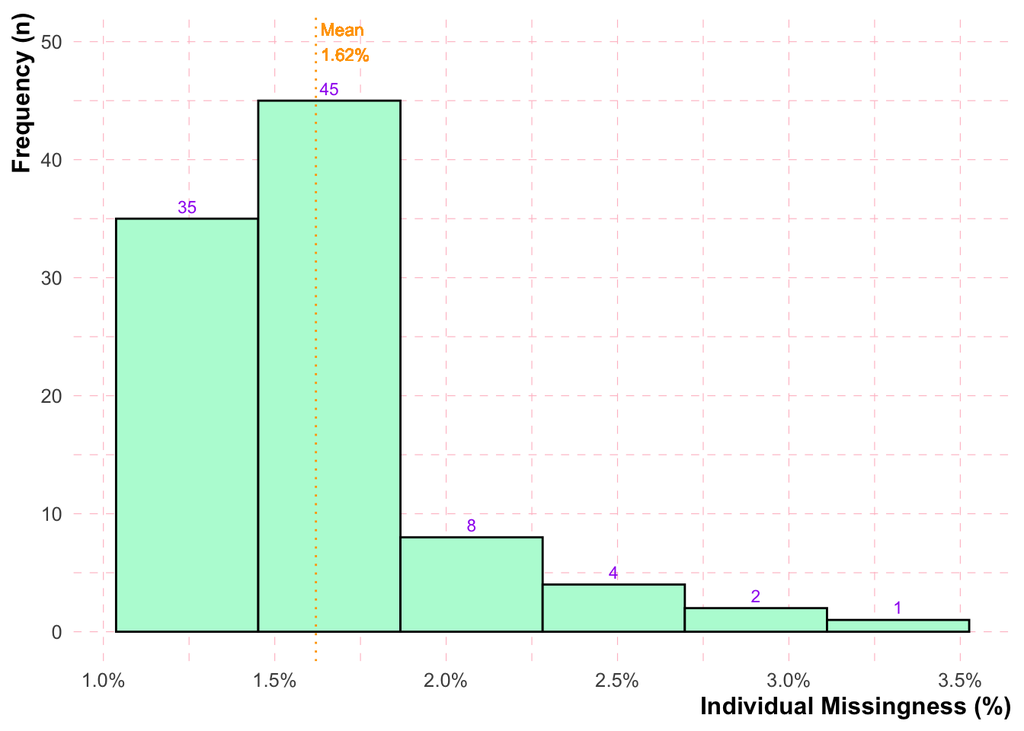

```r
# This code uses the ggplot2 package to create a histogram of the variable F_MISS from the dataset indmiss. The code customizes several aspects of the plot to improve its clarity and visual appeal.
#
# The geom_histogram function specifies the color and fill of the bars, as well as the number of bins to use. The stat_bin function adds text labels to each bin indicating the number of observations in that bin. The geom_vline function adds a vertical dotted line at the position of the mean of F_MISS, while geom_text adds a text label indicating the value of the mean as a percentage.
#
# The labs function is used to label the x and y axes of the plot, while theme_minimal customizes the font and size of the plot elements. The scale_x_continuous function modifies the x-axis to display percentages, and the theme function further modifies the appearance of the grid lines and axis labels.
#
# Overall, this code provides a clear and visually appealing representation of the distribution of F_MISS in the indmiss dataset.

# load plotting theme
source(
  here(
    "scripts", "analysis", "my_theme2.R"
  )
)

# Pre-calculate the mean of F_MISS
mean_f_miss <- mean(indmiss$F_MISS)

# Your ggplot code with the modifications
ggplot(indmiss, aes(x = F_MISS)) +
  geom_histogram(
    color = "black",
    fill = "#B6FAD7",
    bins = 6
  ) +
  geom_text(
    stat = "bin",
    aes(label = after_stat(count)),
    vjust = -0.5,
    color = "purple",
    size = 3,
    bins = 6
  ) +
  geom_vline(
    xintercept = mean_f_miss,
    color = "orange",
    linetype = "dotted",
    linewidth = .5
  ) +
  geom_text(
    aes(x = mean_f_miss, y = 50,
        label = paste0("Mean \n", scales::percent(mean_f_miss, accuracy = 0.01))),
    size = 3,
    color = "orange",
    hjust = -.1
  ) +
  labs(
    x = "Individual Missingness (%)",
    y = "Frequency (n)"
  ) +
  my_theme() +
  scale_x_continuous(
    labels = scales::percent,
    n.breaks = 6
  )
```

```r
#
# save the plot
ggsave(
  here(
    "output", "quality_control", "figures" , "individual_missingness.pdf"
  ),
  width              = 7,
  height             = 5,
  units              = "in"
)
```

Plot variant missingness

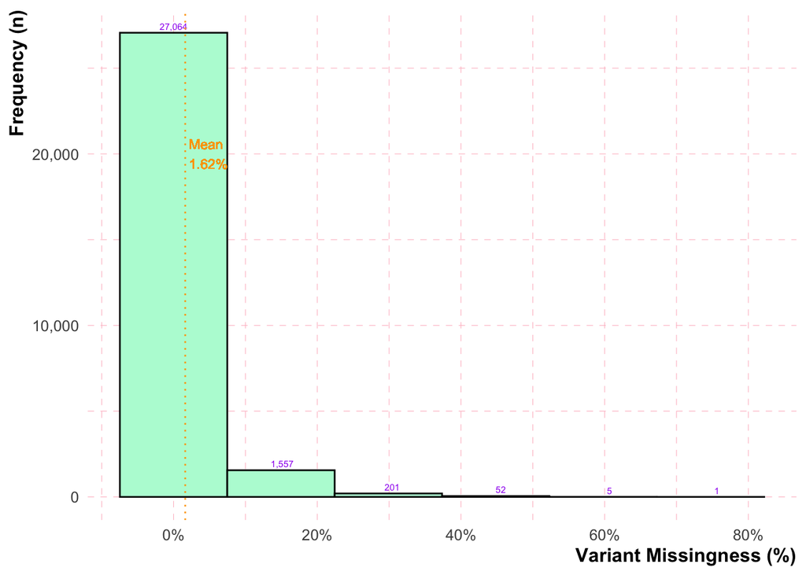

```r
# This plot takes a while to compute
# This code creates a histogram from the indmiss data set using the F_MISS column.
# ggplot builds a histogram of individual missingness data

# Pre-calculate the mean of F_MISS
mean_f_miss <- mean(snpmiss$F_MISS)

ggplot(
  snpmiss,
  aes(
    x = F_MISS
  )
) +
  geom_histogram(
    color = "black",
    fill = "#B6FAD7",
    bins = 6
  ) +
  stat_bin(
    geom = "text",
    aes(
      label = format(
        after_stat(count),
        big.mark = ",",
        scientific = FALSE
      )
    ),
    vjust = -0.5,
    color = "purple",
    size = 2,
    bins = 6
  ) +
   geom_vline(
    xintercept = mean_f_miss,
    color = "orange",
    linetype = "dotted",
    linewidth = .5
  ) +
  geom_text(
    aes(x = mean_f_miss, y = 20000,
        label = paste0("Mean \n", scales::percent(mean_f_miss, accuracy = 0.01))),
    size = 3,
    color = "orange",
    hjust = -.1
  ) +
  labs(
    x = "Variant Missingness (%)",
    y = "Frequency (n)"
  ) +
  scale_x_continuous(
    labels = scales::percent,
    n.breaks = 6
  ) +
  scale_y_continuous(
    labels = scales::label_comma(),
    n.breaks = 5
  ) +
  my_theme()
```

```r
# save the plot
ggsave(
  here(
    "output", "quality_control", "figures", "SNPs_missingness.pdf"
  ),
  width  = 7,
  height = 5,
  units  = "in"
)
```

Remove individuals missing more than 20% of SNPs. You can use the threshold you want, change the flag –mind

```bash
plink2 \
--allow-extra-chr \
--bfile output/quality_control/file5 \
--mind 0.2               `# here we set the individual missingness threshold of 20%`\
--make-bed \
--out output/quality_control/file6 \
--silent;
grep "samples\|variants" output/quality_control/file6.log
```

```
## 95 samples (51 females, 44 males; 95 founders) loaded from
## 28552 variants loaded from output/quality_control/file5.bim.
## 0 samples removed due to missing genotype data (--mind).
## 95 samples (51 females, 44 males; 95 founders) remaining after main filters.
```

We did not remove any SNP due to individual missingness

### 3.2 Minor allele frequency

First lets make a plot of the MAF. First, we estimate the allele frequency with Plink.

```bash
plink2 \
--allow-extra-chr \
--bfile output/quality_control/file6 \
--freq \
--out output/quality_control/MAF_check \
--silent
```

Then we plot it with ggplot.

```r
#   ____________________________________________________________________________
#   Import MAF data                                                         ####
maf_freq <-
  read.delim(
    here(
      "output", "quality_control", "MAF_check.afreq"
    ),
    header = TRUE
  )
```

Make MAF plot

[figure not shown]

```r
#   ____________________________________________________________________________
#   make the plot                                                           ####
ggplot(
  maf_freq,
  aes(ALT_FREQS)
) +
  geom_histogram(
    colour = "black",
    fill = "#C4F3F5",
    bins = 40
  ) +
  labs(
    x = "Minor Allele Frequency (MAF)",
    y = "Frequency (n)",
    caption = "<span style='color:red;'><i>Red</i></span> <span style='color:black;'><i>line at</i></span><span style='color:red;'><i> MAF 10%</i></span><span style='color:black;'><i> threshold</i></span>."
  ) +
  geom_text(
    aes(
      x = .1,
      y = 8000,
      label = paste0("12,471 SNPs")
    ),
    size = 3,
    color = "blue",
    vjust = -.2
  ) +
  geom_vline(xintercept = 0.01, color = "red") +
  my_theme() +
  theme(plot.caption = element_markdown()) +
  scale_y_continuous(label = scales::number_format(big.mark = ",")) +
  scale_x_continuous(breaks = c(0, 0.1, 0.2, 0.3, 0.4), limits = c(-0.01, 0.5))
```

```r
#   ____________________________________________________________________________
#   save the plot                                                           ####
ggsave(
  here(
    "output", "quality_control", "figures", "MAF.pdf"
  ),
  width  = 5,
  height = 4,
  units  = "in"
)
```

Now we apply the MAF filter.

```bash
# We will use MAF of 1%
plink2 \
--allow-extra-chr \
--bfile output/quality_control/file6 \
--maf 0.01 \
--make-bed \
--out output/quality_control/file7 \
--silent;
grep "variants" output/quality_control/file7.log
```

```bash
mkdir -p output/quality_control/hardy;
cp output/quality_control/file7.* output/quality_control/hardy/
```

### 3.3 HWE test

Now we can run the HWE test. However, we will need to apply the SNP missingness again for each population. If we do not, the HWE will vary widely. With the bash script below, we will create a new file for each population, run the HWE test with HWE p value <1e‐6 (HWE p value <1e‐6). Then, we ask Plink to generate a list of SNPs that passed the test for each population.

```bash
for fam in $(awk '{print $1}' output/quality_control/hardy/file7.fam | sort | uniq);
do
echo $fam | \
plink2 \
--allow-no-sex \
--silent \
--keep-allele-order \
--bfile output/quality_control/hardy/file7 \
--keep-fam /dev/stdin \
--make-bed \
--out output/quality_control/hardy/$fam \
--hwe 0.000001 \
--geno 0.1 \
--write-snplist; \
done
```

Next, we use “cat” and “`awk`” to concatenate the SNP list from all populations, and remove duplicates. Once we have a list of SNPs that passed the test for each population, we can use Plink to create a new bed file keeping only the SNPs that passed the test in each population. First, lets get the list of SNPs, and count how many passed:

```bash
cat output/quality_control/hardy/*.snplist | awk '!a[$0]++' > output/quality_control/passed_hwe.txt;
wc -l output/quality_control/passed_hwe.txt
```

[output not shown]

How many variants we had before

```bash
cat output/quality_control/file7.bim | awk '{print $2}'| awk '!a[$0]++' | wc -l
```

```
##    16081
```

Variants not passing HWE test

```r
16081 - 16025
```

```
## [1] 56
```

### 3.5 LD pruning

```bash
# you can change the values of indep-pairwise to see how many more variants are pruned. Ideally, we would use linkage network analysis to remove variants based on the interspersed or mosaic like block distribution.
# we set a window of variants of 5 and move the window 1 variant per time, removing 1 of the variants with lowest MAF from a pair above the threshold of r^2 > 0.1
# Try --indep-pairwise 50kb 1 0.1 to see.
plink2 \
--bfile output/quality_control/file7 \
--extract output/quality_control/passed_hwe.txt \
--indep-pairwise 50kb 1 0.1 \
--out output/quality_control/indepSNP \
--silent;
grep 'pairwise\|variants\|samples' output/quality_control/indepSNP.log
```

Remember, the SNPs are not removed from our data set. Plink created 3 files when we run the code above. One is the “indepSNP.log” file, and the other two are:  
“**indepSNP.prune.in**” -> list of SNPs with squared correlation smaller than our r2 threshold of 0.1.  
“i**ndepSNP.prune.out**” -> list of SNPs with squared correlation greater than our r2 threshold of 0.1. For our heterozygosity estimates, we want to use the set of SNPs that are below our r2 threshold of 0.1. We consider that they are randomly associated. We can use Plink to estimate the heterozygosity using the “indepSNP.prune.in” file.

### 3.6 Heterozygosity

```bash
plink2 \
--allow-extra-chr \
--bfile output/quality_control/file7 \
--extract output/quality_control/indepSNP.prune.in \
--het \
--out output/quality_control/R_check \
--silent;
grep 'variants' output/quality_control/R_check.log
```

```
## 16081 variants loaded from output/quality_control/file7.bim.
## --extract: 10157 variants remaining.
## 10157 variants remaining after main filters.
```

```r
#   ____________________________________________________________________________
#   find individuals with high heterozygosity                              ####
# import the data from Plink
het <- read.delim(
  here(
    "output", "quality_control", "R_check.het"
  ),
  head = TRUE
)
#
# check head of the file
colnames(het)
```

```
## [1] "X.FID"  "IID"    "O.HOM." "E.HOM." "OBS_CT" "F"
```

Estimate het

```r
# create a column named HET_RATE and calculate the heterozygosity rate
het$HET_RATE <- (het$"OBS_CT" - het$"O.HOM") / het$"OBS_CT"
#
# use subset function to get values deviating from 4sd of the mean heterozygosity rate.
het_fail <-
  subset(
    het, (het$HET_RATE < mean(
      het$HET_RATE
    ) - 4 * sd(
      het$HET_RATE
    )) |
      (het$HET_RATE > mean(
        het$HET_RATE
      ) + 4 * sd(
        het$HET_RATE
      ))
  )
#
# get the list of individuals that failed our threshold of 4sd from the mean.
het_fail$HET_DST <-
  (het_fail$HET_RATE - mean(
    het$HET_RATE
  )) / sd(
    het$HET_RATE
  )
```

Save the files to use with Plink

```r
#   ____________________________________________________________________________
#   save the data to use with Plink2                                        ####
#
write.table(
  het_fail,
  here(
    "output", "quality_control", "fail-het-qc.txt"
  ),
  row.names = FALSE
)
```

Make plot

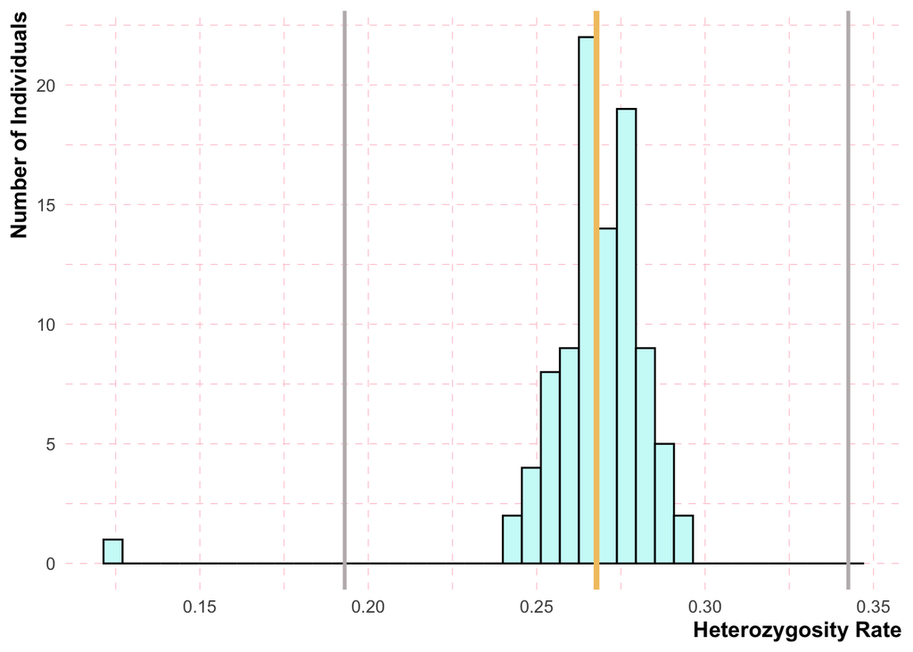

```r
#   ____________________________________________________________________________
#   make a heterozygosity plot                                              ####
#
ggplot(
  het,
  aes(
    HET_RATE
  )
) +
  geom_histogram(
    colour           = "black",
    fill             = "#CDFAF8",
    bins             = 40
  ) +
  labs(
    x                = "Heterozygosity Rate",
    y                = "Number of Individuals"
  ) +
  geom_vline(
    aes(
      xintercept     = mean(
        HET_RATE
      )
    ),
    col              = "#F2C46F",
    linewidth        = 1.5
  ) +
  geom_vline(
    aes(
      xintercept     = mean(
        HET_RATE
      ) + 4 * sd(
        HET_RATE
      )
    ),
    col              = "#BFB9B9",
    linewidth        = 1
  ) +
  geom_vline(
    aes(
      xintercept     = mean(
        HET_RATE
      ) - 4 * sd(
        HET_RATE
      )
    ),
    col              = "#BFB9B9",
    linewidth        = 1
  ) +
  my_theme() +
  scale_y_continuous(
    labels           = comma
  )
```

```r
#   ____________________________________________________________________________
#   save the heterozygosity plot                                            ####
ggsave(
  here(
    "output", "quality_control", "figures", "Heterozygosity.pdf"
  ),
  width  = 5,
  height = 4,
  units  = "in"
)
```

```bash
sed 's/"// g' output/quality_control/fail-het-qc.txt | awk '{print$1, $2}'> output/quality_control/het_fail_ind.txt;
echo 'How many mosquitoes we need to remove from our data set:';
cat output/quality_control/het_fail_ind.txt | tail -n +2 | wc -l;
echo 'Which mosquitoes we have to remove:';
tail -n +2 output/quality_control/het_fail_ind.txt
```

```
## How many mosquitoes we need to remove from our data set:
##        1
## Which mosquitoes we have to remove:
## Background_Female_Alive 59
```

Next, we will remove these mosquitoes from our data set using Plink:

```bash
plink2 \
--allow-extra-chr \
--bfile output/quality_control/file7 \
--remove output/quality_control/het_fail_ind.txt \
--make-bed \
--out output/quality_control/file8 \
--silent;
grep 'variants\|samples' output/quality_control/file8.log
```

### 3.7 Relatedness

Check for cryptic relatedness. Check Plink2 documentation https://www.cog-genomics.org/plink/2.0/distance You can download King directly https://www.kingrelatedness.com/manual.shtml or check their manuscript https://www.ncbi.nlm.populations.gov/pmc/articles/PMC3025716/pdf/btq559.pdf From Plink2 documentation: “Note that KING kinship coefficients are scaled such that duplicate samples have kinship 0.5, not 1. First-degree relations (parent-child, full siblings) correspond to ~0.25, second-degree relations correspond to ~0.125, etc. It is conventional to use a cutoff of ~0.354 (the geometric mean of 0.5 and 0.25) to screen for monozygotic twins and duplicate samples, ~0.177 to add first-degree relations, etc.” There two options. One is to run only –make-king and another one is to use –make-king-table We will use the threshold of 0.354 and create a table.

```bash
# --make-king-table rel-check \  use this if you have more than 1 family
# Plink2 will create a file with extension .king
plink2 \
--allow-extra-chr \
--bfile output/quality_control/file8 \
--extract output/quality_control/indepSNP.prune.in \
--make-king-table rel-check \
--king-table-filter 0.354 \
--out output/quality_control/file9 \
--silent;
grep 'variants\|samples' output/quality_control/file9.log
```

```
## 94 samples (50 females, 44 males; 94 founders) loaded from
## 16081 variants loaded from output/quality_control/file8.bim.
## --extract: 10157 variants remaining.
## 10157 variants remaining after main filters.
```

Check the individuals that did not pass our filtering.

```bash
head output/quality_control/file9.kin0
```

```
## #FID1    IID1    FID2    IID2    NSNP    HETHET  IBS0    KINSHIP
## Selection_Female_Alive   6   Selection_Female_Alive  1   9871    0.243136    0.00344443  0.429551
```

We want to remove one of the individuals of the pairs.

```bash
plink2 \
--allow-extra-chr \
--bfile output/quality_control/file8 \
--extract output/quality_control/indepSNP.prune.in \
--make-king triangle bin \
--out output/quality_control/file9 \
--silent;
grep 'variants\|samples' output/quality_control/file9.log
```

```
## 94 samples (50 females, 44 males; 94 founders) loaded from
## 16081 variants loaded from output/quality_control/file8.bim.
## --extract: 10157 variants remaining.
## 10157 variants remaining after main filters.
## --make-king pass 1/1: Scanning for rare variants... done.
## 426 variants handled by initial scan (9731 remaining).
## --make-king: 10157 variants processed.
```

Now we can use Plink2 to remove one of the mosquitoes from the pair with high kinship.

```bash
plink2 \
--allow-extra-chr \
--bfile output/quality_control/file8 \
--king-cutoff output/quality_control/file9 0.354 \
--make-bed \
--extract output/quality_control/indepSNP.prune.in \
--out output/quality_control/file10 \
--silent;
grep 'samples\|variants\|remaining' output/quality_control/file10.log
```

```
## 94 samples (50 females, 44 males; 94 founders) loaded from
## 16081 variants loaded from output/quality_control/file8.bim.
## --extract: 10157 variants remaining.
## 10157 variants remaining after main filters.
## output/quality_control/file10.king.cutoff.out.id , and 89 remaining sample IDs
```

Now we can check the individuals that were removed.

```bash
# we have 5 samples that were removed, and our file has heading, so we need to see 13 lines of the file
head -n 10 output/quality_control/file10.king.cutoff.out.id
```

```
## #FID IID
## Background_Female_Dead   79
## Background_Female_Alive  84
## Selection_Female_Alive   6
## Selection_Female_Alive   27
## Selection_Male_Alive 41
```

### 3.8 Quick PCA with Plink using the LD pruned data after removing the related individuals.

We will run PCA analysis with LEA latter, but we can get a quick PCA using Plink.

PCA

```bash
plink2 \
--allow-no-sex \
--bfile output/quality_control/file10 \
--pca allele-wts \
--freq \
--out output/quality_control/pca_pops \
--silent;
grep 'samples\|variants' output/quality_control/pca_pops.log
```

```
## Note: --allow-no-sex no longer has any effect.  (Missing-sex samples are
## 89 samples (46 females, 43 males; 89 founders) loaded from
## 10157 variants loaded from output/quality_control/file10.bim.
```

Check the files

```bash
head -n 2 output/quality_control/pca_pops.eigenvec
```

```
## #FID IID PC1 PC2 PC3 PC4 PC5 PC6 PC7 PC8 PC9 PC10
## Background_Female_Dead   49  -0.0517459  0.0129325   -0.0263857  0.0142222   0.0691695   -0.0944059  0.164304    -0.00950409 0.162263    0.0445865
```

```bash
head -n 3 output/quality_control/pca_pops.eigenval
```

```
## 9.41577
## 2.83948
## 2.4992
```

Import PCA data

```r
# import the data from Plink
pca <- read.delim(
  here(
    "output", "quality_control", "pca_pops.eigenvec"
  ),
  head = TRUE
)

# check head of the file
head(pca)
```

```
##                    X.FID IID        PC1        PC2         PC3         PC4
## 1 Background_Female_Dead  49 -0.0517459  0.0129325 -0.02638570  0.01422220
## 2 Background_Female_Dead  50 -0.0551241  0.0139858 -0.01199770  0.00570965
## 3 Background_Female_Dead  51  0.1589630  0.2031490  0.04011980 -0.26566800
## 4 Background_Female_Dead  52 -0.0600769 -0.0243143 -0.00369734 -0.03740980
## 5 Background_Female_Dead  53 -0.0597811 -0.1618970  0.00195743 -0.07142830
## 6 Background_Female_Dead  54 -0.0514635  0.0533898  0.03991300  0.06394770
##           PC5        PC6        PC7         PC8        PC9       PC10
## 1  0.06916950 -0.0944059  0.1643040 -0.00950409  0.1622630  0.0445865
## 2 -0.00157925  0.0260858  0.0121895  0.16712200  0.0716350 -0.0597622
## 3 -0.00179186  0.1192390 -0.0537646  0.03195540 -0.0429254 -0.0835911
## 4 -0.10230700  0.0671276  0.0453212  0.17461600  0.0748909  0.2219210
## 5  0.13637400  0.0310443 -0.0430002 -0.08229920  0.1297490 -0.0227683
## 6  0.10414300  0.0673897 -0.0366687  0.07340210 -0.1084830  0.0252052
```

Check number of samples per population

```r
pops_pca <-
  pca |>
  group_by(X.FID) |>
  summarize(count_distinct = n_distinct(IID))

# check it
head(pops_pca)
```

```
## # A tibble: 5 × 2
##   X.FID                   count_distinct
##   <chr>                            <int>
## 1 Background_Female_Alive              5
## 2 Background_Female_Dead              19
## 3 Background_Male_Dead                20
## 4 Selection_Female_Alive              22
## 5 Selection_Male_Alive                23
```

PC1 and PC2

```r
# Create new columns
pca <- pca |>
  separate(X.FID, into = c("Phenotype", "Sex", "Status"), sep = "_", remove = FALSE)
head(pca)
```

```
##                    X.FID  Phenotype    Sex Status IID        PC1        PC2
## 1 Background_Female_Dead Background Female   Dead  49 -0.0517459  0.0129325
## 2 Background_Female_Dead Background Female   Dead  50 -0.0551241  0.0139858
## 3 Background_Female_Dead Background Female   Dead  51  0.1589630  0.2031490
## 4 Background_Female_Dead Background Female   Dead  52 -0.0600769 -0.0243143
## 5 Background_Female_Dead Background Female   Dead  53 -0.0597811 -0.1618970
## 6 Background_Female_Dead Background Female   Dead  54 -0.0514635  0.0533898
##           PC3         PC4         PC5        PC6        PC7         PC8
## 1 -0.02638570  0.01422220  0.06916950 -0.0944059  0.1643040 -0.00950409
## 2 -0.01199770  0.00570965 -0.00157925  0.0260858  0.0121895  0.16712200
## 3  0.04011980 -0.26566800 -0.00179186  0.1192390 -0.0537646  0.03195540
## 4 -0.00369734 -0.03740980 -0.10230700  0.0671276  0.0453212  0.17461600
## 5  0.00195743 -0.07142830  0.13637400  0.0310443 -0.0430002 -0.08229920
## 6  0.03991300  0.06394770  0.10414300  0.0673897 -0.0366687  0.07340210
##          PC9       PC10
## 1  0.1622630  0.0445865
## 2  0.0716350 -0.0597622
## 3 -0.0429254 -0.0835911
## 4  0.0748909  0.2219210
## 5  0.1297490 -0.0227683
## 6 -0.1084830  0.0252052
```

Plot it

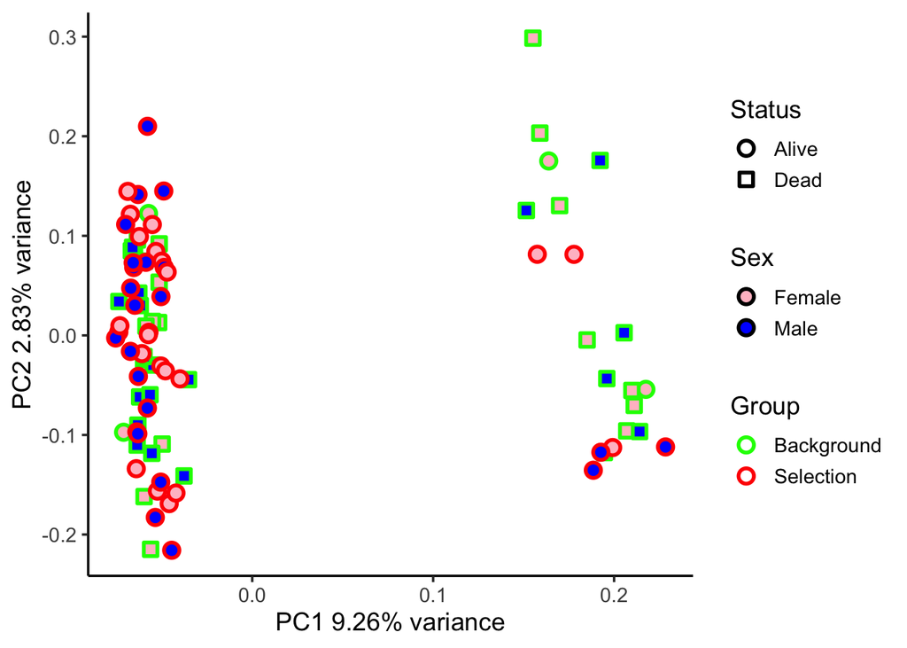

```r
# Plot it
ggplot(pca, aes(PC1, PC2, colour = Phenotype, fill = Sex, shape = Status)) +
  geom_point(size = 3, stroke = 1.5) +
  scale_shape_manual(values = c(21, 22)) +
  scale_fill_manual(values = c("Female" = "pink", "Male" = "blue")) +
  scale_color_manual(values = c("green", "red")) +
  theme_classic(base_size = 14) +
  xlab("PC1 9.26% variance") +
  ylab("PC2 2.83% variance") +
  labs(colour = "Group", fill = "Sex", shape = "Status") +
  guides(fill = guide_legend(override.aes = list(shape = 21)),
         colour = guide_legend(override.aes = list(shape = 21)))
```

```r
#   ____________________________________________________________________________
#   save the pca plot                                                       ####
ggsave(
  here(
    "output", "quality_control", "figures", "PCA_pc1_2_plink.pdf"
  ),
  width  = 10,
  height = 6,
  units  = "in"
)
```

PC1 and PC3

[figure not shown]

```r
# Plot it
ggplot(pca, aes(PC1, PC3, colour = Phenotype, fill = Sex, shape = Status)) +
  geom_point(size = 3, stroke = 1.5) +
  scale_shape_manual(values = c(21, 22)) +
  scale_fill_manual(values = c("Female" = "pink", "Male" = "blue")) +
  scale_color_manual(values = c("green", "red")) +
  theme_classic(base_size = 14) +
  xlab("PC1 9.26% variance") +
  ylab("PC2 2.48% variance") +
  labs(colour = "Group", fill = "Sex", shape = "Status") +
  guides(fill = guide_legend(override.aes = list(shape = 21)),
         colour = guide_legend(override.aes = list(shape = 21)))
```

```r
#   ____________________________________________________________________________
#   save the pca plot                                                       ####
ggsave(
  here(
    "output", "quality_control", "figures", "PCA_pc1_3_plink.pdf"
  ),
  width  = 10,
  height = 6,
  units  = "in"
)
```

We can get a list of each group, so we can subset it later

```r
head(pca)
```

```
##                    X.FID  Phenotype    Sex Status IID        PC1        PC2
## 1 Background_Female_Dead Background Female   Dead  49 -0.0517459  0.0129325
## 2 Background_Female_Dead Background Female   Dead  50 -0.0551241  0.0139858
## 3 Background_Female_Dead Background Female   Dead  51  0.1589630  0.2031490
## 4 Background_Female_Dead Background Female   Dead  52 -0.0600769 -0.0243143
## 5 Background_Female_Dead Background Female   Dead  53 -0.0597811 -0.1618970
## 6 Background_Female_Dead Background Female   Dead  54 -0.0514635  0.0533898
##           PC3         PC4         PC5        PC6        PC7         PC8
## 1 -0.02638570  0.01422220  0.06916950 -0.0944059  0.1643040 -0.00950409
## 2 -0.01199770  0.00570965 -0.00157925  0.0260858  0.0121895  0.16712200
## 3  0.04011980 -0.26566800 -0.00179186  0.1192390 -0.0537646  0.03195540
## 4 -0.00369734 -0.03740980 -0.10230700  0.0671276  0.0453212  0.17461600
## 5  0.00195743 -0.07142830  0.13637400  0.0310443 -0.0430002 -0.08229920
## 6  0.03991300  0.06394770  0.10414300  0.0673897 -0.0366687  0.07340210
##          PC9       PC10
## 1  0.1622630  0.0445865
## 2  0.0716350 -0.0597622
## 3 -0.0429254 -0.0835911
## 4  0.0748909  0.2219210
## 5  0.1297490 -0.0227683
## 6 -0.1084830  0.0252052
```

Filter by PC1

Group A

```r
groupR <- pca |>
  dplyr::filter(PC1 < 0) |>
  dplyr::select(X.FID, IID)

length(groupR$X.FID)
```

```
## [1] 68
```

Grupo B

```r
groupS <- pca |>
  dplyr::filter(PC1 > 0)|>
  dplyr::select(X.FID, IID)

length(groupS$X.FID)
```

```
## [1] 21
```

```r
head(groupR)
```

```
##                    X.FID IID
## 1 Background_Female_Dead  49
## 2 Background_Female_Dead  50
## 3 Background_Female_Dead  52
## 4 Background_Female_Dead  53
## 5 Background_Female_Dead  54
## 6 Background_Female_Dead  55
```

```r
head(groupS)
```

```
##                     X.FID IID
## 1  Background_Female_Dead  51
## 2  Background_Female_Dead  58
## 3 Background_Female_Alive  72
## 4  Background_Female_Dead  73
## 5  Background_Female_Dead  74
## 6  Background_Female_Dead  75
```

Save group R

```r
# Save and override the .fam file for dp
write.table(
  groupR,
  file      = here(
    "output", "quality_control", "groupR.txt"
  ),
  sep       = "\t",
  row.names = FALSE,
  col.names = FALSE,
  quote     = FALSE
)
```

Save group S

```r
# Save and override the .fam file for dp
write.table(
  groupS,
  file      = here(
    "output", "quality_control", "groupS.txt"
  ),
  sep       = "\t",
  row.names = FALSE,
  col.names = FALSE,
  quote     = FALSE
)
```

## 5. Plot SNP density

After quality control and pruning

```r
# load the function that we saved earlier
source(
  here(
    "scripts", "analysis", "import_bim.R"
  ),
  local = knitr::knit_global()
)
# import the file
snp_den_qc <- import_bim(
  here(
    "output", "quality_control", "file10.bim"
  )
)
```

Make plot of the SNP density

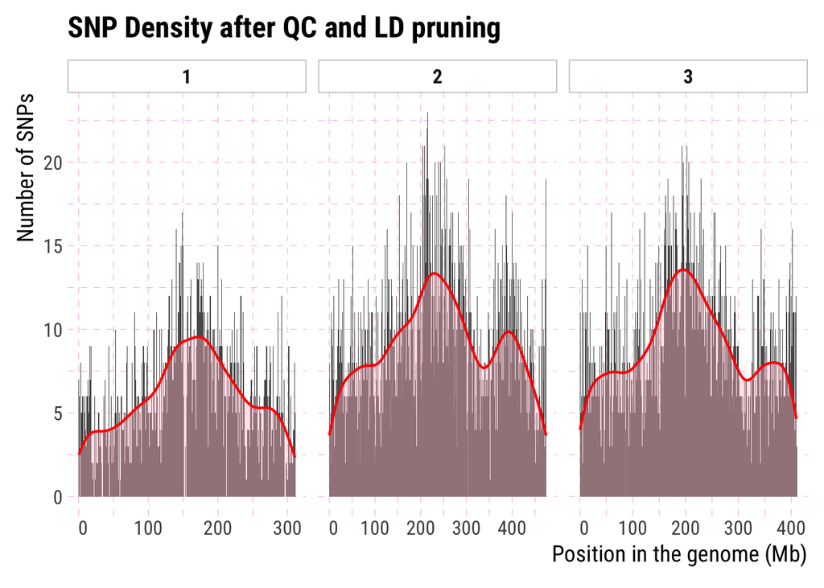

```r
#   ____________________________________________________________________________
#   plot SNP density after QC                                               ####
snp_den_qc |>
  rename(
    Chromosome = 1
  ) |>
  mutate(
    Position           = as.numeric(
      Position
    )
  ) |>
  ggplot(
    aes(
      x                = Position
    ),
    label              = sprintf(
      "%0.2f",
      round(
        a,
        digits         = 0
      )
    )
  ) +
  geom_histogram(
    aes(
      y                = after_stat(
        count
      )
    ),
    binwidth           = 1e6
  ) +
  facet_wrap(
    vars(
      Chromosome
    ),
    scales             = "free_x"
  ) +
  labs(
    title              = "SNP Density after QC and LD pruning",
    x                  = expression(
      "Position in the genome (Mb)"
    ),
    y                  = expression(
      "Number of SNPs"
    )
  ) +
  scale_x_continuous(
    labels             = function(x) {
      format(
        x / 1e6,
        big.mark       = ",",
        scientific     = FALSE
      )
    }
  ) +
  geom_density(
  aes(
    y = 1e6 * after_stat(count)
  ),
  color = "red",
  linewidth = .75,
  alpha = .4,
  fill = "pink"
  ) +
  hrbrthemes::theme_ipsum(
    base_family        = "Roboto Condensed",
    axis_text_size     = 12,
    axis_title_size    = 14,
    plot_margin        = margin(
      10, 10, 10, 10
    ),
    grid               = TRUE,
    grid_col           = "#fabbe2"
  ) +
  theme(
    panel.grid.major   = element_line(
      linetype         = "dashed",
      linewidth        = 0.2
    ),
    panel.grid.minor   = element_line(
      linetype         = "dashed",
      linewidth        = 0.2
    ),
    panel.spacing      = unit(0.5, "lines"),
    strip.text         = element_text(
      face             = "bold", hjust = .5
    ),
    strip.background.x = element_rect(
      color            = "gray"
    )
  )
```

```r
#   ____________________________________________________________________________
#   save the density plot                                            ####
ggsave(
  here(
    "output", "quality_control","figures", "snp_density_after_qc.pdf"
  ),
  width  = 10,
  height = 6,
  units  = "in"
)
```

SNPs per chromosome

```r
# we can use dplyr "count" to get the number of SNPs for each chromosome
# lets get the data we need
snps_per_chrm <-
  snp_den_qc |>
  count(
    Scaffold) |>
  rename(
    Chromosome = 1,
    "SNPs (N) " = 2
  )

# Create the flextable
ft <- flextable::flextable(snps_per_chrm)

# Apply zebra theme
ft <- flextable::theme_zebra(ft)

# Add a caption to the table
ft <- flextable::add_header_lines(ft, "SNPs per chromosome after quality control")
ft
```

| SNPs per chromosome after quality control Chromosome | SNPs per chromosome after quality control SNPs (N) |
| --- | --- |
| 1 | 1,953 |
| 2 | 4,418 |
| 3 | 3,786 |

We can get the mean number of SNPs per chromosome or the entire genome

```r
# we first use dplyr cut_width to get the number of SNPs per 1Mb window
albo_den <-
  snp_den_qc |>
  dplyr::select(
    Scaffold, Position
  ) |>
  group_by(
    Scaffold,
    windows               = cut_width(
      Position,
      width               = 1e6,
      boundary            = 0
    )
  ) |>
  summarise(
    n                     = n(),
    .groups               = "keep"
  ) |>
  group_by(
    Scaffold
  ) |>
  summarise(
    mean                  = mean(n),
    n                     = n(),
    .groups               = "keep"
  ) |>
  rename(
    Chromosome            = 1,
    "SNPs per 1Mb window" = 2,
    "Number of windows"   = 3
  )
#
# check the results
snp_table <-
  flextable(
    albo_den
  )
snp_table <- colformat_double(
  x        = snp_table,
  big.mark = ",",
  digits   = 2,
  na_str   = "N/A"
)
snp_table
```

| Chromosome | SNPs per 1Mb window | Number of windows |
| --- | --- | --- |
| 1 | 6.38 | 306 |
| 2 | 9.32 | 474 |
| 3 | 9.23 | 410 |

Merge objects

```r
# we can merge the two data sets we created above into one table
after_qc <-
  snps_per_chrm |>
  left_join(
    albo_den,
    by = "Chromosome"
  )
snp_table2 <- flextable(
  after_qc)
snp_table2 <- colformat_double(
  x        = snp_table2,
  big.mark = ",",
  digits   = 2,
  na_str   = "N/A"
  )
snp_table2
```

| Chromosome | SNPs (N) | SNPs per 1Mb window | Number of windows |
| --- | --- | --- | --- |
| 1 | 1,953 | 6.38 | 306 |
| 2 | 4,418 | 9.32 | 474 |
| 3 | 3,786 | 9.23 | 410 |

## 6. GWAS

We can use Plink to perform an GWAS. First let’s take a look at the PCA

### 6.1 Histogram of phenotypes

```r
read_fam_file <-
function(file_path) {
  fam_data <- readr::read_delim(
    file = file_path,
    col_types = "ccccccc",
    col_names = FALSE
  )
  return(fam_data)
}
```

```r
fam2 <- read_fam_file(here(
  "output", "quality_control", "file1.fam"
))

# Rename columns
fam2 <- fam2 |>
  dplyr::rename(
    FamilyID = X1,
    IndividualID = X2,
    PaternalID = X3,
    MaternalID = X4,
    Sex = X5,
    Phenotype = X6
  )

# Make it numeric
fam2$Phenotype <- as.numeric(fam2$Phenotype)

head(fam2)
```

```
## # A tibble: 6 × 6
##   FamilyID               IndividualID PaternalID MaternalID Sex   Phenotype
##   <chr>                  <chr>        <chr>      <chr>      <chr>     <dbl>
## 1 Background_Female_Dead 49           0          0          2             1
## 2 Background_Female_Dead 50           0          0          2             1
## 3 Background_Female_Dead 51           0          0          2             1
## 4 Background_Female_Dead 52           0          0          2             1
## 5 Background_Female_Dead 53           0          0          2             1
## 6 Background_Female_Dead 54           0          0          2             1
```

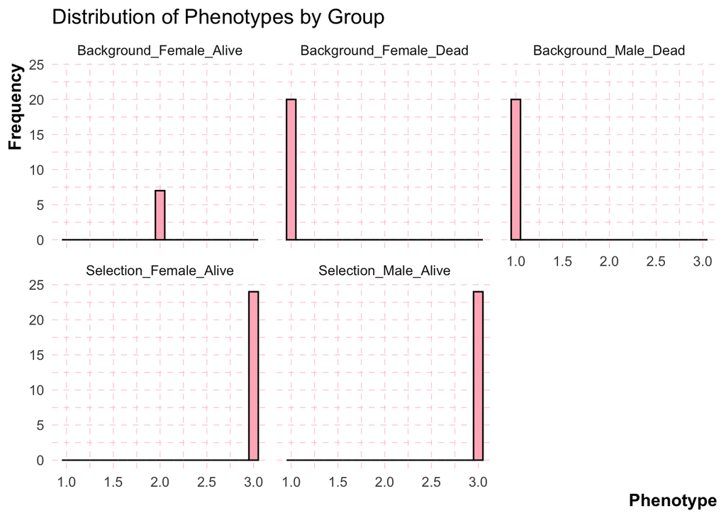

```r
# source the plotting function
source(
  here(
    "scripts", "analysis", "my_theme2.R"
  )
)

# Create a faceted histogram
ggplot(fam2, aes(x = Phenotype)) +
  geom_histogram(binwidth = 0.1, color = "black", fill = "lightpink") +  # Adjust binwidth as needed
  facet_wrap(~ FamilyID) +  # Create a facet for each FamilyID
  labs(x = "Phenotype",
       y = "Frequency",
       title = "Distribution of Phenotypes by Group") +
  my_theme()
```

We will compare selection alive vs background dead. We need to filter out the data set. We need to remove Background_Female_Alive

```r
unique(fam2$FamilyID)
```

```
## [1] "Background_Female_Dead"  "Background_Female_Alive"
## [3] "Background_Male_Dead"    "Selection_Female_Alive"
## [5] "Selection_Male_Alive"
```

```r
fam3 <- fam2 |>
  dplyr::filter(FamilyID != "Background_Female_Alive") |>
  dplyr::select(FamilyID, IndividualID)
head(fam3)
```

```
## # A tibble: 6 × 2
##   FamilyID               IndividualID
##   <chr>                  <chr>
## 1 Background_Female_Dead 49
## 2 Background_Female_Dead 50
## 3 Background_Female_Dead 51
## 4 Background_Female_Dead 52
## 5 Background_Female_Dead 53
## 6 Background_Female_Dead 54
```

Save it

```r
# Save
write.table(
  fam3,
  file      = here(
    "output", "gwas", "mosquitoes_gwas.txt"
  ),
  sep       = "\t",
  row.names = FALSE,
  col.names = FALSE,
  quote     = FALSE
)
```

Subset

```bash
plink \
--keep-allele-order \
--bfile output/quality_control/file10 \
--keep output/gwas/mosquitoes_gwas.txt \
--make-bed \
--out output/gwas/file1 \
--silent;
grep 'samples\|variants' output/gwas/file1.log
```

```
## 10157 variants loaded from .bim file.
## Total genotyping rate in remaining samples is 0.978539.
## 10157 variants and 84 people pass filters and QC.
```

Now let’s look at the PCA to see if we have clusters in our data

### 6.2 PCA

PCA

```bash
plink2 \
--allow-no-sex \
--bfile output/gwas/file1 \
--pca allele-wts \
--freq \
--out output/gwas/pca_pops \
--silent;
grep 'samples\|variants' output/gwas/pca_pops.log
```

```
## Note: --allow-no-sex no longer has any effect.  (Missing-sex samples are
## 84 samples (41 females, 43 males; 84 founders) loaded from
## 10157 variants loaded from output/gwas/file1.bim.
```

Check the files

```bash
head -n 2 output/gwas/pca_pops.eigenvec
```

```
## #FID IID PC1 PC2 PC3 PC4 PC5 PC6 PC7 PC8 PC9 PC10
## Background_Female_Dead   49  -0.052701   0.0204888   0.0126055   -0.0443451  0.0995356   -0.11786    -0.08456    -0.126808   0.158825    0.0687246
```

```bash
head -n 3 output/gwas/pca_pops.eigenval
```

```
## 8.77365
## 2.75291
## 2.37382
```

Import PCA data

```r
# import the data from Plink
pca <- read.delim(
  here(
    "output", "gwas", "pca_pops.eigenvec"
  ),
  head = TRUE
)

# check head of the file
head(pca)
```

```
##                    X.FID IID        PC1         PC2         PC3         PC4
## 1 Background_Female_Dead  49 -0.0527010  0.02048880  0.01260550 -0.04434510
## 2 Background_Female_Dead  50 -0.0562471  0.00986815  0.00260754 -0.02410130
## 3 Background_Female_Dead  51  0.1687270  0.21260800 -0.25049500  0.14781500
## 4 Background_Female_Dead  52 -0.0618490 -0.03017660 -0.03093860 -0.00804768
## 5 Background_Female_Dead  53 -0.0610369 -0.16636600 -0.04113060  0.05562780
## 6 Background_Female_Dead  54 -0.0510563  0.05158430  0.05786710  0.03069240
##           PC5        PC6        PC7         PC8         PC9       PC10
## 1  0.09953560 -0.1178600 -0.0845600 -0.12680800  0.15882500  0.0687246
## 2 -0.04407120  0.0228466 -0.1204500 -0.07807440  0.01636000 -0.0580565
## 3 -0.00808628  0.1706990 -0.0301235 -0.00923613 -0.07204430  0.1097240
## 4 -0.11927100  0.0678635 -0.1977480 -0.07471120  0.12710700 -0.1259400
## 5  0.13526800  0.0237850  0.0976885 -0.08785580 -0.00171483 -0.1305280
## 6  0.07004820  0.0625573 -0.0733229  0.07585490 -0.06069930 -0.0611100
```

Check number of samples per population

```r
pops_pca <-
  pca |>
  group_by(X.FID) |>
  summarize(count_distinct = n_distinct(IID))

# check it
head(pops_pca)
```

```
## # A tibble: 4 × 2
##   X.FID                  count_distinct
##   <chr>                           <int>
## 1 Background_Female_Dead             19
## 2 Background_Male_Dead               20
## 3 Selection_Female_Alive             22
## 4 Selection_Male_Alive               23
```

PC1 and PC2

```r
# Create new columns
pca <- pca |>
  separate(X.FID, into = c("Phenotype", "Sex", "Status"), sep = "_", remove = FALSE)
head(pca)
```

```
##                    X.FID  Phenotype    Sex Status IID        PC1         PC2
## 1 Background_Female_Dead Background Female   Dead  49 -0.0527010  0.02048880
## 2 Background_Female_Dead Background Female   Dead  50 -0.0562471  0.00986815
## 3 Background_Female_Dead Background Female   Dead  51  0.1687270  0.21260800
## 4 Background_Female_Dead Background Female   Dead  52 -0.0618490 -0.03017660
## 5 Background_Female_Dead Background Female   Dead  53 -0.0610369 -0.16636600
## 6 Background_Female_Dead Background Female   Dead  54 -0.0510563  0.05158430
##           PC3         PC4         PC5        PC6        PC7         PC8
## 1  0.01260550 -0.04434510  0.09953560 -0.1178600 -0.0845600 -0.12680800
## 2  0.00260754 -0.02410130 -0.04407120  0.0228466 -0.1204500 -0.07807440
## 3 -0.25049500  0.14781500 -0.00808628  0.1706990 -0.0301235 -0.00923613
## 4 -0.03093860 -0.00804768 -0.11927100  0.0678635 -0.1977480 -0.07471120
## 5 -0.04113060  0.05562780  0.13526800  0.0237850  0.0976885 -0.08785580
## 6  0.05786710  0.03069240  0.07004820  0.0625573 -0.0733229  0.07585490
##           PC9       PC10
## 1  0.15882500  0.0687246
## 2  0.01636000 -0.0580565
## 3 -0.07204430  0.1097240
## 4  0.12710700 -0.1259400
## 5 -0.00171483 -0.1305280
## 6 -0.06069930 -0.0611100
```

Plot it

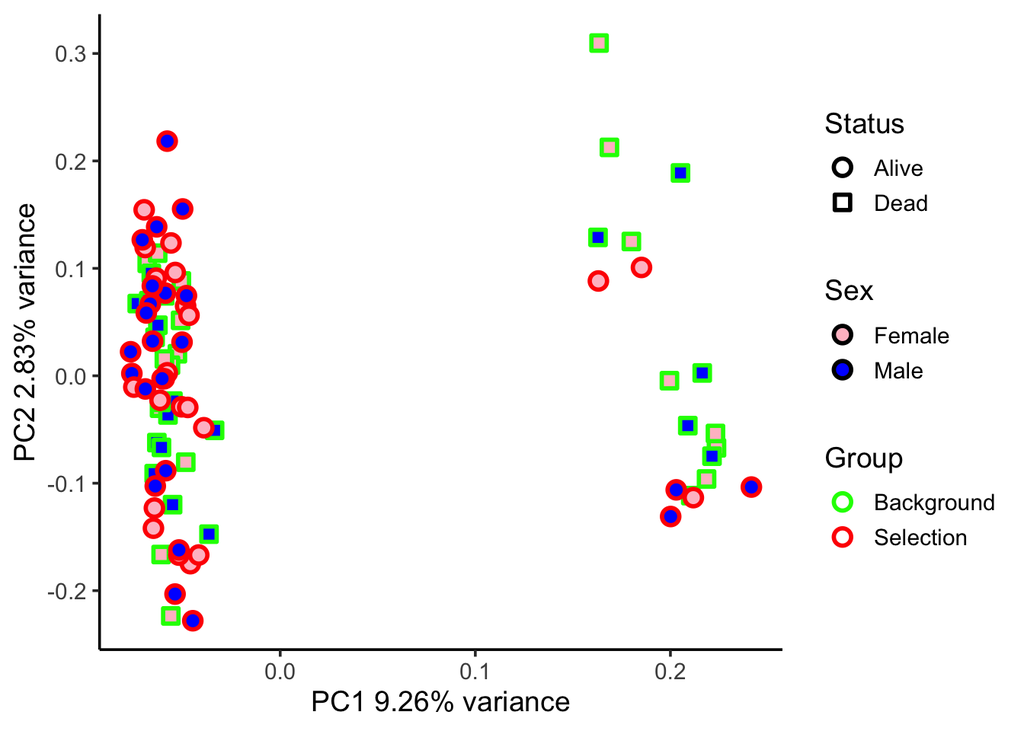

```r
# Plot it
ggplot(pca, aes(PC1, PC2, colour = Phenotype, fill = Sex, shape = Status)) +
  geom_point(size = 3, stroke = 1.5) +
  scale_shape_manual(values = c(21, 22)) +
  scale_fill_manual(values = c("Female" = "pink", "Male" = "blue")) +
  scale_color_manual(values = c("green", "red")) +
  theme_classic(base_size = 14) +
  xlab("PC1 9.26% variance") +
  ylab("PC2 2.83% variance") +
  labs(colour = "Group", fill = "Sex", shape = "Status") +
  guides(fill = guide_legend(override.aes = list(shape = 21)),
         colour = guide_legend(override.aes = list(shape = 21)))
```

```r
#   ____________________________________________________________________________
#   save the pca plot                                                       ####
ggsave(
  here(
    "output", "gwas", "figures", "PCA_pc1_2_plink.pdf"
  ),
  width  = 10,
  height = 6,
  units  = "in"
)
```

Subset

```bash
plink \
--keep-allele-order \
--bfile output/gwas/file1 \
--keep output/gwas/mosquitoes_gwas.txt \
--make-bed \
--out output/gwas/file2 \
--silent;
grep 'samples\|variants' output/gwas/file2.log
```

```
## 10157 variants loaded from .bim file.
## 10157 variants and 84 people pass filters and QC.
```

### 6.2 Perform MDS analysis and create a covar.txt file

```bash
# Create .genome file
plink \
--keep-allele-order \
--allow-extra-chr \
--bfile output/gwas/file2 \
--genome \
--out output/gwas/file3 \
--silent;
grep 'samples\|variants' output/gwas/file3.log
```

```
## 10157 variants loaded from .bim file.
## 10157 variants and 84 people pass filters and QC.
```

MDS with 10 vectors

```bash
# Make mds with 10 vectors
plink \
--keep-allele-order \
--bfile output/gwas/file2 \
--read-genome output/gwas/file3.genome \
--cluster \
--mds-plot 10 \
--out output/gwas/file2_mds \
--silent;
grep 'samples\|variants' output/gwas/file2_mds.log
```

```
## 10157 variants loaded from .bim file.
## 10157 variants and 84 people pass filters and QC.
```

Create covar

```bash
# Change the format of the .mds file into a plink covariate file.
awk '{print$1, $2, $4, $5, $6, $7, $8, $9, $10, $11, $12, $13}' output/gwas/file2_mds.mds > output/gwas/covar_mds.txt;
head output/gwas/covar_mds.txt
```

```
## FID IID C1 C2 C3 C4 C5 C6 C7 C8 C9 C10
## Background_Female_Dead 49 -0.0314221 0.0109494 -7.40515e-05 0.0661541 -0.00316283 0.00210679 -0.0417995 0.0222941 -0.0113046 0.0338092
## Background_Female_Dead 50 -0.0395128 0.00813479 0.0196518 -0.0139654 -0.000122796 -0.0366771 -0.0278407 -0.0175587 -0.0669804 -0.0364288
## Background_Female_Dead 51 0.110434 0.0342871 -0.00897997 -0.0453781 -0.0336895 0.0614204 -0.00609363 0.0103278 -0.00636031 -0.0301665
## Background_Female_Dead 52 -0.0405477 -0.00954674 0.0228072 -0.0385411 0.00855535 -0.00561607 -0.0560286 -0.0129216 -0.0112726 0.0241853
## Background_Female_Dead 53 -0.0384312 -0.0653027 -0.0172593 0.0225481 -0.0436758 -0.0133979 0.0434553 -0.04181 -0.0569459 0.0148556
## Background_Female_Dead 54 -0.0326187 0.0298171 -0.0104888 -0.0122768 -0.0388041 -0.0199141 0.000210038 -0.00255352 0.00127618 -0.0214512
## Background_Female_Dead 55 -0.0330811 0.0201846 -0.00040096 0.0143447 0.0024297 0.010046 0.0173826 -0.0229041 -0.0240689 0.0240543
## Background_Female_Dead 56 -0.0436466 0.0444712 -0.111094 0.0110261 -0.0369204 -0.0459294 -0.00871212 0.00152102 0.00842958 -0.0463507
## Background_Female_Dead 57 -0.0275266 -0.0375883 -0.0436829 -0.013518 0.0244275 -0.000895937 0.0193133 0.0357159 -0.01789 0.0289837
```

### 6.3 GWAS linear

Run the association

```bash
plink \
--keep-allele-order \
--bfile output/gwas/file2 \
--covar output/gwas/covar_mds.txt \
--linear hide-covar \
--maf 0.05 \
--adjust \
--out output/gwas/linear
```

[output not shown]

```bash
head output/gwas/linear.assoc.linear.adjusted
```

```
##  CHR           SNP      UNADJ         GC       BONF       HOLM   SIDAK_SS   SIDAK_SD     FDR_BH     FDR_BY
##    2   AX-93231649  4.365e-05  6.482e-05     0.3703     0.3703     0.3095     0.3095     0.3182          1
##    2   AX-93253321  7.501e-05  0.0001094     0.6364     0.6363     0.4708     0.4708     0.3182          1
##    3   AX-93232994  0.0001879  0.0002642          1          1     0.7969     0.7968     0.4002          1
##    2   AX-93235352  0.0002635  0.0003658          1          1     0.8931      0.893     0.4002          1
##    2   AX-93244070  0.0002655  0.0003685          1          1     0.8949     0.8948     0.4002          1
##    1   AX-93248562  0.0002831  0.0003919          1          1     0.9094     0.9093     0.4002          1
##    2   AX-93218421   0.000339  0.0004653          1          1     0.9437     0.9436     0.4109          1
##    3   AX-93226503  0.0007805   0.001037          1          1     0.9987     0.9987     0.6089          1
##    3   AX-93216036  0.0007956   0.001057          1          1     0.9988     0.9988     0.6089          1
```

### 6.4 GWAS logistic

```bash
plink \
--keep-allele-order \
--bfile output/gwas/file2 \
--covar output/gwas/covar_mds.txt \
--pheno output/gwas/phenotypes.txt \
--maf 0.05 \
--logistic hide-covar \
--adjust \
--out output/gwas/logistic
```

[output not shown]

```bash
head output/gwas/logistic.assoc.logistic.adjusted
```

```
##  CHR           SNP      UNADJ         GC       BONF       HOLM   SIDAK_SS   SIDAK_SD     FDR_BH     FDR_BY
##    2   AX-93231649  0.0001739  0.0006957          1          1     0.7712     0.7712     0.7975          1
##    2   AX-93235352  0.0005128     0.0017          1          1     0.9871     0.9871     0.7975          1
##    3   AX-93232994  0.0005692   0.001853          1          1      0.992      0.992     0.7975          1
##    1   AX-93248562  0.0006307   0.002018          1          1     0.9952     0.9952     0.7975          1
##    3   AX-93249248   0.001293   0.003655          1          1          1          1     0.7975          1
##    1   AX-93235909   0.001364    0.00382          1          1          1          1     0.7975          1
##    3   AX-93216036   0.001392   0.003886          1          1          1          1     0.7975          1
##    1   AX-93263439   0.001584   0.004325          1          1          1          1     0.7975          1
##    2   AX-93259901   0.001699   0.004582          1          1          1          1     0.7975          1
```

### 6.5 Manhattan plots

Linear

```r
# Not adjusted
linear <-
  read.table(here("output", "gwas", "linear.assoc.linear"),
             head = TRUE)
# If there are any, you can clean them like this
linear <- linear[!is.na(linear$P) & !is.infinite(-log10(linear$P)),]


pdf("output/gwas/figures/linear_manhattan.pdf", width = 8, height = 6)
manhattan(
  linear,
  chr = "CHR",
  bp = "BP",
  p = "P",
  snp = "SNP",
  col = c("#b9ff8e", "#ffa9ff", "#ffce9c"),
  chrlabs = c ("Chr1", "Chr2", "Chr3"),
  main = "Manhattan plot: Linear",
  annotatePval = TRUE,
  annotateTop = TRUE
)
dev.off()
```

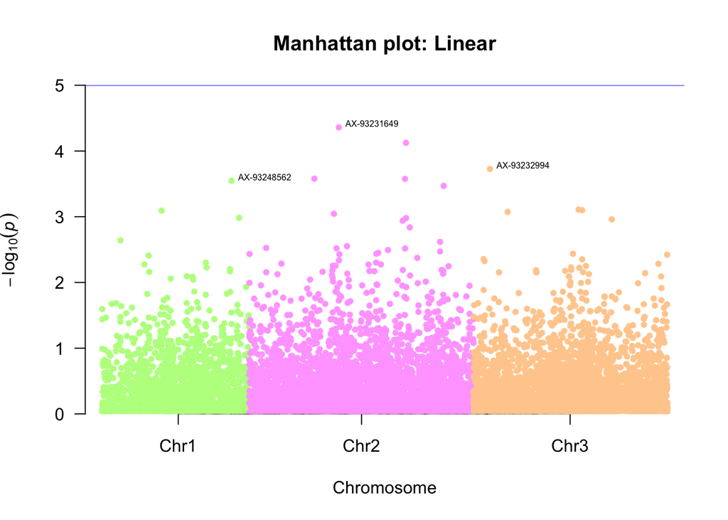

```r
manhattan(
  linear,
  chr = "CHR",
  bp = "BP",
  p = "P",
  snp = "SNP",
  col = c("#b9ff8e", "#ffa9ff", "#ffce9c"),
  chrlabs = c ("Chr1", "Chr2", "Chr3"),
  main = "Manhattan plot: Linear",
  annotatePval = TRUE,
  annotateTop = TRUE)
```

Logistic

```r
# Not adjusted
logistic <-
  read.table(here("output", "gwas", "logistic.assoc.logistic"),
             head = TRUE)
# If there are any, you can clean them like this
logistic <- logistic[!is.na(logistic$P) & !is.infinite(-log10(logistic$P)),]


pdf("output/gwas/figures/logistic_manhattan.pdf", width = 8, height = 6)
manhattan(
  logistic,
  chr = "CHR",
  bp = "BP",
  p = "P",
  snp = "SNP",
  col = c("#b9ff8e", "#ffa9ff", "#ffce9c"),
  chrlabs = c ("Chr1", "Chr2", "Chr3"),
  main = "Manhattan plot: logistic",
  annotatePval = TRUE,
  annotateTop = TRUE
)
dev.off()
```

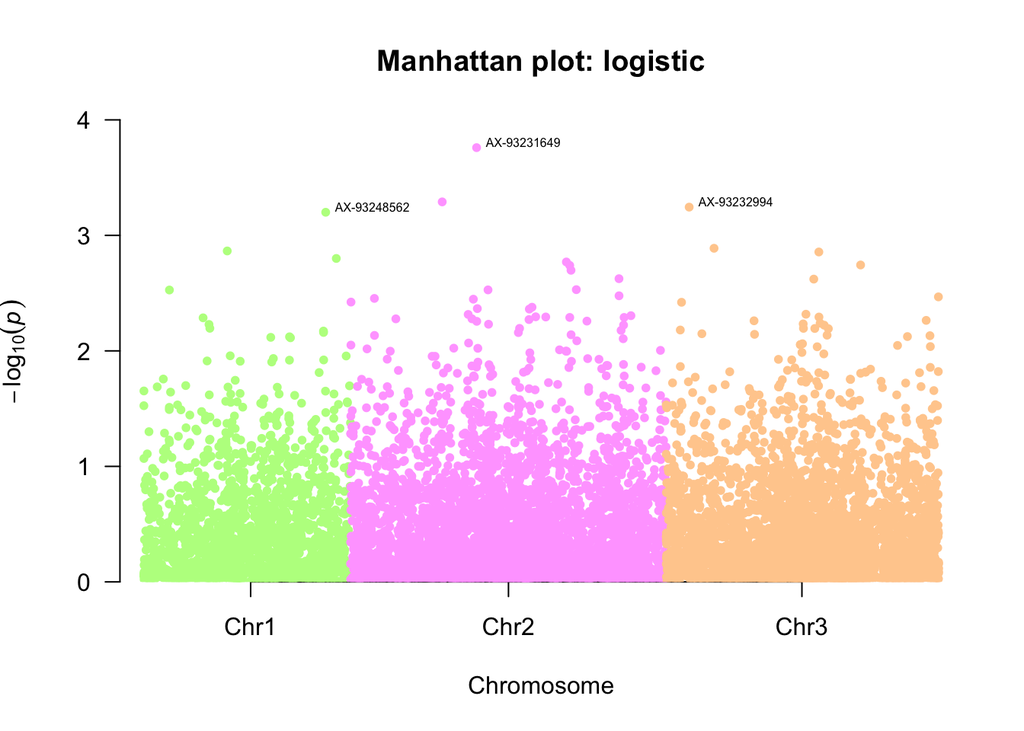

```r
manhattan(
  logistic,
  chr = "CHR",
  bp = "BP",
  p = "P",
  snp = "SNP",
  col = c("#b9ff8e", "#ffa9ff", "#ffce9c"),
  chrlabs = c ("Chr1", "Chr2", "Chr3"),
  main = "Manhattan plot: logistic",
  annotatePval = TRUE,
  annotateTop = TRUE)
```

How many SNPs

```r
# Not adjusted
logistic_adjusted <-
  read.table(here("output", "gwas", "logistic.assoc.logistic.adjusted"),
             head = TRUE)

logistic_adjusted |>
  filter(
    BONF <= 0.05
  )
```

```
##  [1] CHR      SNP      UNADJ    GC       BONF     HOLM     SIDAK_SS SIDAK_SD
##  [9] FDR_BH   FDR_BY
## <0 rows> (or 0-length row.names)
```